# Tugas Praktikum MPDW 6

## Packages

```r
library(ggplot2)
library(tsibble)
library(tseries)
library(MASS)
library(forecast)
library(TSA)
library(TTR)
library(aTSA)
library(graphics)
library(readxl)
```

## Input Seluruh Data

### Data

```r
data <- read_xlsx("C:/Users/Delia/OneDrive/Documents/Semester 5/Metode Peramalan Deret Waktu/Praktikum/Tugas/Pertemuan 6/Data tugas 6.xlsx")
data
```

```
## # A tibble: 100 × 2
##    Periode             Kendaraan
##    <dttm>                  <dbl>
##  1 2024-02-08 00:00:00     58790
##  2 2024-02-09 00:00:00     31121
##  3 2024-02-10 00:00:00     29444
##  4 2024-02-11 00:00:00     24777
##  5 2024-02-12 00:00:00     24370
##  6 2024-02-13 00:00:00     27939
##  7 2024-02-14 00:00:00     19336
##  8 2024-02-15 00:00:00     23742
##  9 2024-02-16 00:00:00     29353
## 10 2024-02-17 00:00:00     30447
## # ℹ 90 more rows
```

### Mengubah Data Asli jadi Time Series

```r
data$Kendaraan <- ts(data$Kendaraan)
data$Periode <- as.Date(data$Periode)
data
```

```
## # A tibble: 100 × 2
##    Periode    Kendaraan
##    <date>         <dbl>
##  1 2024-02-08     58790
##  2 2024-02-09     31121
##  3 2024-02-10     29444
##  4 2024-02-11     24777
##  5 2024-02-12     24370
##  6 2024-02-13     27939
##  7 2024-02-14     19336
##  8 2024-02-15     23742
##  9 2024-02-16     29353
## 10 2024-02-17     30447
## # ℹ 90 more rows
```

### Eksplorasi Data

#### Plot Time Series

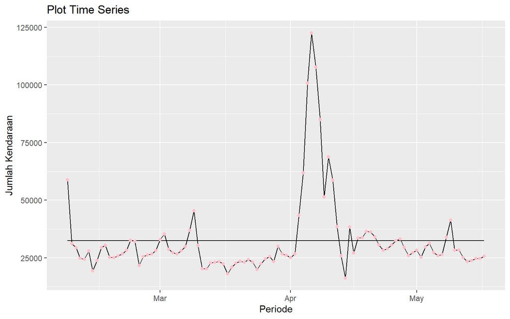

```r
ggplot(data, aes(x = Periode, y = Kendaraan)) +
  geom_line(y = mean(data$Kendaraan, color = "yellow"))+
  geom_line(color = "black") +
  geom_point(color = "pink") +
  labs(title = "Plot Time Series", x = "Periode", y = "Jumlah Kendaraan")
```

### Cek Kestasioneran

#### Plot ACF

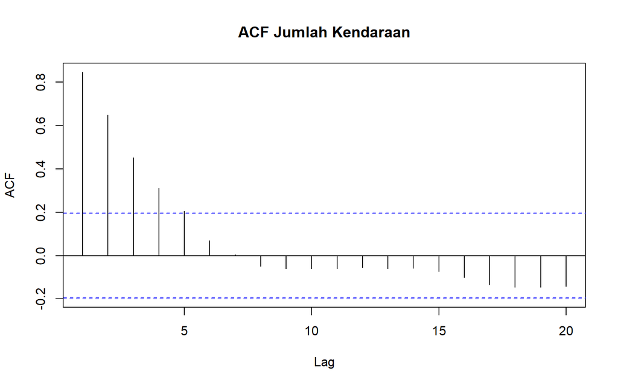

```r
acf(data$Kendaraan, main="ACF Jumlah Kendaraan",lag.max = 20)
```

Berdasarkan plot ACF, terlihat bahwa plot ACF data menurun secara perlahan (*tails of slowly*). Hal ini juga menjadi indikasi bahwa data tidak stasioner dalam rataan

#### Uji ADF

```r
tseries::adf.test(data$Kendaraan)
```

```
##
##  Augmented Dickey-Fuller Test
##
## data:  data$Kendaraan
## Dickey-Fuller = -2.9555, Lag order = 4, p-value = 0.1808
## alternative hypothesis: stationary
```

$H_0$ : Data tidak stasioner dalam rataan

$H_1$ : Data stasioner dalam rataan

Berdasarkan uji ADF tersebut, didapat *p-value* sebesar 0.1808 yang lebih besar dari taraf nyata 5% sehingga tak cukup bukti untuk menolak $H_0$ dan menandakan bahwa data tidak stasioner dalam rataan.

#### Uji Box-Cox

```r
n <- nrow(data)
index <- seq(1:n)
bc = boxcox(data$Kendaraan~index)
```

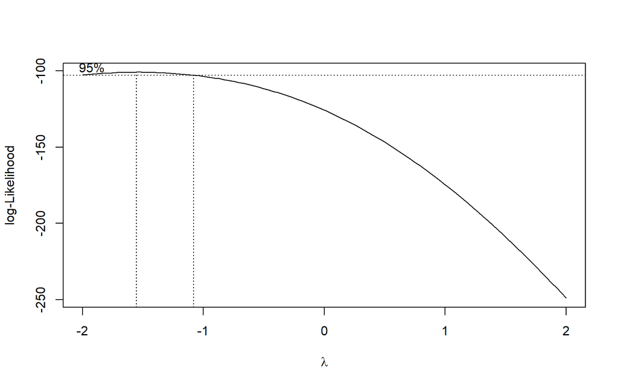

```r
#Nilai Rounded Lambda
lambda <- bc$x[which.max(bc$y)]
lambda
```

```
## [1] -1.555556
```

```r
#SK
bc$x[bc$y > max(bc$y) - 1/2 * qchisq(.95,1)]
```

```
##  [1] -2.000000 -1.959596 -1.919192 -1.878788 -1.838384 -1.797980 -1.757576
##  [8] -1.717172 -1.676768 -1.636364 -1.595960 -1.555556 -1.515152 -1.474747
## [15] -1.434343 -1.393939 -1.353535 -1.313131 -1.272727 -1.232323 -1.191919
## [22] -1.151515 -1.111111
```

Gambar di atas menunjukkan nilai *rounded value* ($\lambda$) optimum sebesar **-1.56** dan pada selang kepercayaan 95% nilai memiliki batas bawah **-2.0** dan batas atas **-1.11**. Selang tersebut tidak memuat nilai satu sehingga dapat dikatakan bahwa data tidak stasioner dalam ragam.

**Kesimpulan** :Seluruh data tidak stasioner dalam rataan maupun ragam.

## Data Latih dan Data Uji

```r
# Data Latih
data.train <- data[1:80,2]
data.train.ts <- ts(data.train)
data.train.ts
```

```
## Time Series:
## Start = 1
## End = 80
## Frequency = 1
##       Kendaraan
##  [1,]     58790
##  [2,]     31121
##  [3,]     29444
##  [4,]     24777
##  [5,]     24370
##  [6,]     27939
##  [7,]     19336
##  [8,]     23742
##  [9,]     29353
## [10,]     30447
```

[output cut: 70 more lines]

```r
# Data Uji
data.test <- data[81:100,2]
data.test.ts <- ts(data.test)
data.test.ts
```

```
## Time Series:
## Start = 1
## End = 20
## Frequency = 1
##       Kendaraan
##  [1,]     29601
##  [2,]     26026
##  [3,]     27256
##  [4,]     28246
##  [5,]     25194
##  [6,]     29703
##  [7,]     31300
##  [8,]     27203
##  [9,]     25922
## [10,]     26417
## [11,]     33873
## [12,]     41390
## [13,]     28230
## [14,]     28380
## [15,]     25070
## [16,]     23411
## [17,]     23814
## [18,]     24618
## [19,]     24674
## [20,]     25733
```

### Eksplorasi Data Latih dan Data Uji

#### Plot Time Series

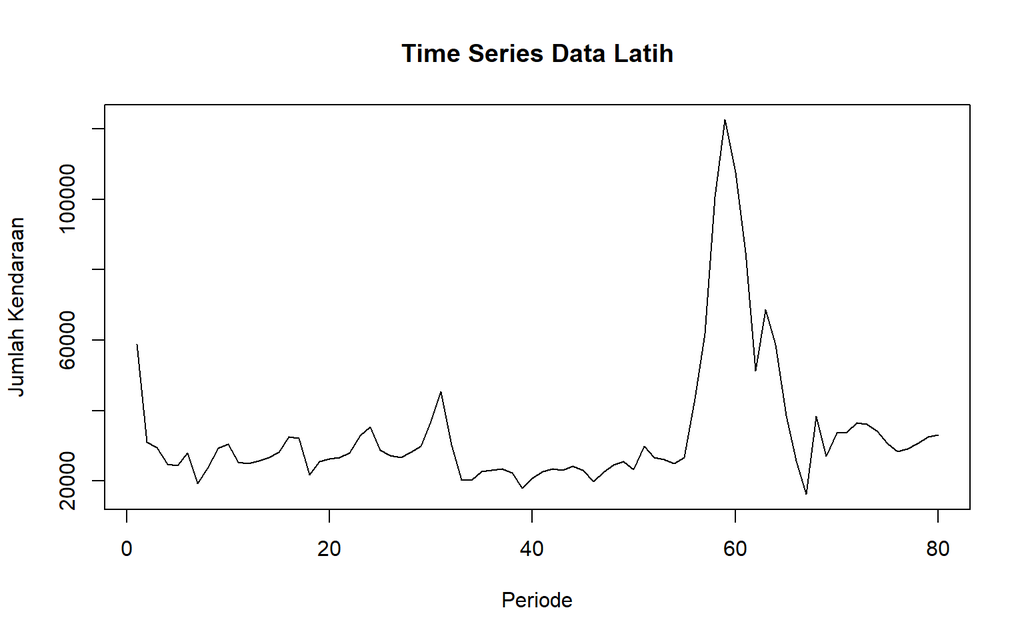

```r
# Data Latih
plot.ts(data.train.ts, lty=1, xlab="Periode", ylab="Jumlah Kendaraan", main="Time Series Data Latih")
```

Berdasarkan plot data deret waktu pada data latih ini kemungkinan tidak stasioner, terutama karena lonjakan besar di sekitar periode 60, yang menunjukkan perubahan signifikan dalam rata-rata dan ragam seiring waktu. Untuk deret waktu yang stasioner, rata-rata dan ragam harus konstan sepanjang periode, dan hal ini tidak terlihat di plot ini.

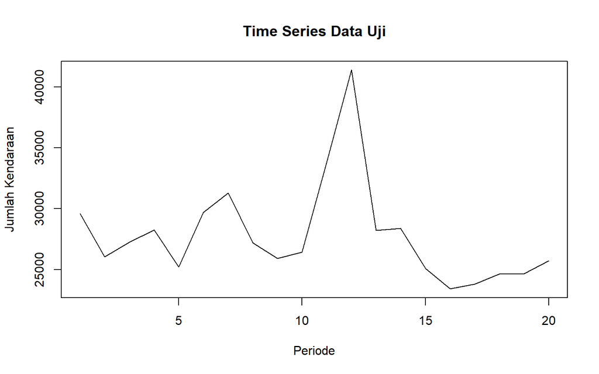

```r
# Data Uji
plot.ts(data.test.ts, lty=1, xlab="Periode", ylab="Jumlah Kendaraan", main="Time Series Data Uji")
```

Berdasarkan plot data deret waktu pada data uji ini kemungkinan tidak stasioner karena terdapat perubahan mendadak dalam ragam pada periode tertentu. Untuk data yang stasioner, seharusnya ragam dan rata-rata relatif konstan sepanjang periode waktu. Lonjakan besar yang terlihat di sekitar periode ke-10 menunjukkan ketidakstabilan dalam ragam, yang menandakan bahwa data ini tidak stasioner.

## Data Latih

### Cek Kestasioneran

#### Plot ACF

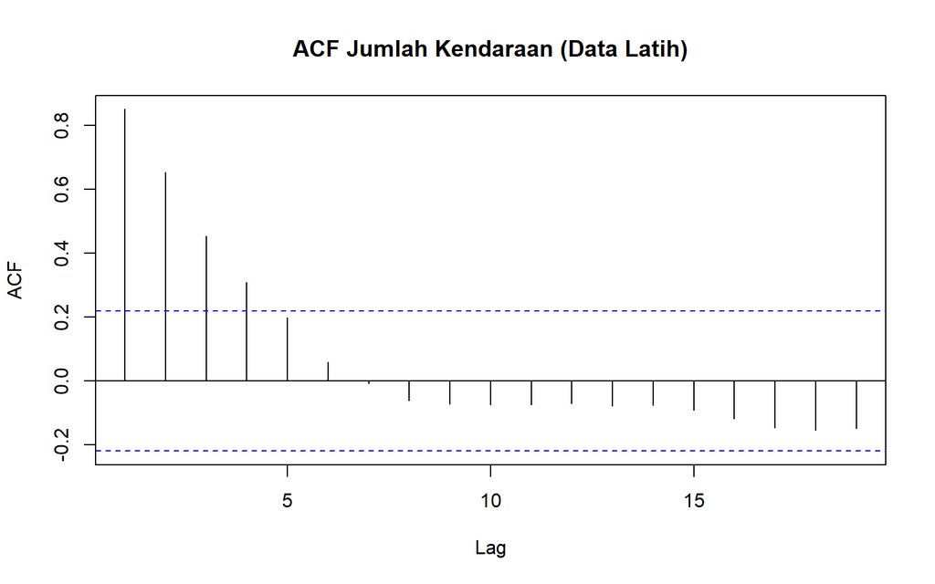

```r
acf(data.train.ts, main="ACF Jumlah Kendaraan (Data Latih)")
```

Berdasarkan plot ACF, terlihat bahwa plot ACF pada data tersebut cenderung *tails off* secara perlahan. Hal ini menjadi indikasi bahwa data tidak stasioner dalam rataan.

#### Uji ADF

```r
tseries::adf.test(data.train.ts)
```

```
##
##  Augmented Dickey-Fuller Test
##
## data:  data.train.ts
## Dickey-Fuller = -2.8312, Lag order = 4, p-value = 0.2356
## alternative hypothesis: stationary
```

$H_0$ : Data tidak stasioner dalam rataan

$H_1$ : Data stasioner dalam rataan

Berdasarkan uji ADF tersebut, didapat *p-value* sebesar 0.2356 yang lebih besar dari taraf nyata 5% sehingga tak cukup bukti untuk menolak $H_0$ dan menandakan bahwa data tidak stasioner dalam rataan.

#### Uji Box-Cox

```r
n <- nrow(data.train.ts)
index <- seq(1:n)
bc = boxcox(data.train.ts~index)
```

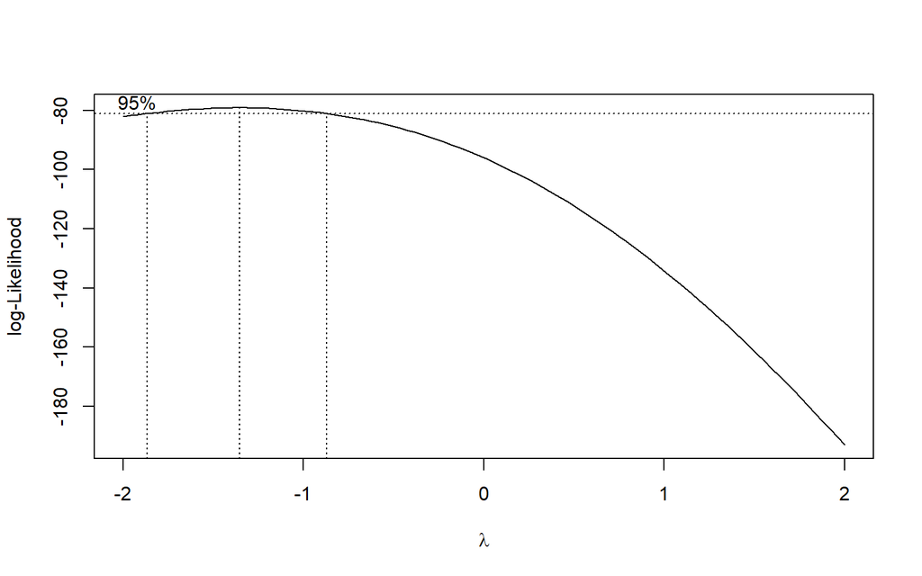

```r
#Nilai Rounded Lambda
lambda <- bc$x[which.max(bc$y)]
lambda
```

```
## [1] -1.353535
```

```r
#SK
bc$x[bc$y > max(bc$y) - 1/2 * qchisq(.95,1)]
```

```
##  [1] -1.8383838 -1.7979798 -1.7575758 -1.7171717 -1.6767677 -1.6363636
##  [7] -1.5959596 -1.5555556 -1.5151515 -1.4747475 -1.4343434 -1.3939394
## [13] -1.3535354 -1.3131313 -1.2727273 -1.2323232 -1.1919192 -1.1515152
## [19] -1.1111111 -1.0707071 -1.0303030 -0.9898990 -0.9494949 -0.9090909
```

Gambar di atas menunjukkan nilai *rounded value* ($\lambda$) optimum sebesar **-1.35** dan pada selang kepercayaan 95% nilai memiliki batas bawah **-1.83** dan batas atas **-0.90**. Selang tersebut tidak memuat nilai satu sehingga dapat dikatakan bahwa data tidak stasioner dalam ragam.

### Penanganan Ketidakstioneran Data

#### Transformasi Box-Cox

```r
lambda <- BoxCox.lambda(data.train.ts)
data.transformasi <- BoxCox(data.train.ts, lambda)
data.transformasi
```

```
## Time Series:
## Start = 1
## End = 80
## Frequency = 1
##       Kendaraan
##  [1,]  2.086547
##  [2,]  2.082590
##  [3,]  2.082185
##  [4,]  2.080852
##  [5,]  2.080719
##  [6,]  2.081791
##  [7,]  2.078736
##  [8,]  2.080506
##  [9,]  2.082162
## [10,]  2.082431
```

[output cut: 72 more lines]

#### Uji Box-Cox

```r
# Jumlah baris data
n <- nrow(data.transformasi)
# Membuat indeks waktu
index <- seq(1:n)
# Melakukan Box-Cox transformation
bc = boxcox(data.transformasi~index)
```

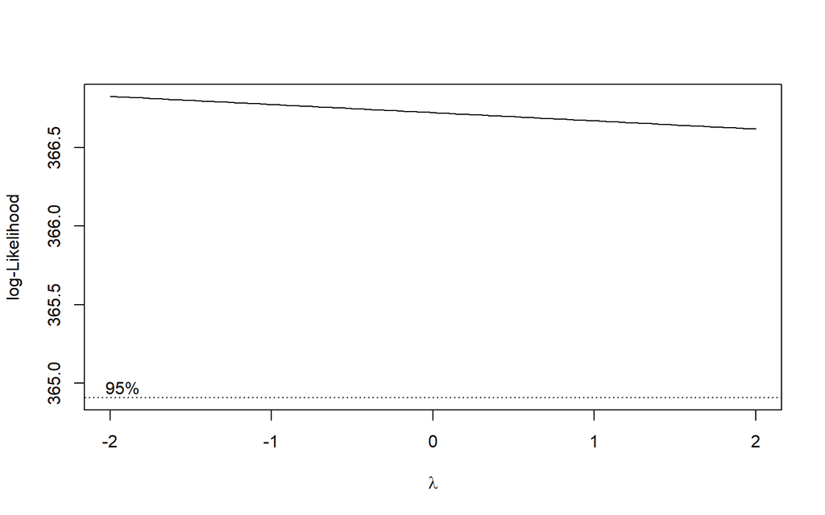

```r
# Mendapatkan nilai lambda optimum (rounded value)
lambda <- bc$x[which.max(bc$y)]
# Menampilkan lambda optimum
cat("Nilai rounded lambda optimum adalah:", lambda, "\n")
```

```
## Nilai rounded lambda optimum adalah: -2
```

```r
#SK
bc$x[bc$y > max(bc$y) - 1/2 * qchisq(.95,1)]
```

```
##   [1] -2.00000000 -1.95959596 -1.91919192 -1.87878788 -1.83838384 -1.79797980
##   [7] -1.75757576 -1.71717172 -1.67676768 -1.63636364 -1.59595960 -1.55555556
##  [13] -1.51515152 -1.47474747 -1.43434343 -1.39393939 -1.35353535 -1.31313131
##  [19] -1.27272727 -1.23232323 -1.19191919 -1.15151515 -1.11111111 -1.07070707
##  [25] -1.03030303 -0.98989899 -0.94949495 -0.90909091 -0.86868687 -0.82828283
##  [31] -0.78787879 -0.74747475 -0.70707071 -0.66666667 -0.62626263 -0.58585859
##  [37] -0.54545455 -0.50505051 -0.46464646 -0.42424242 -0.38383838 -0.34343434
##  [43] -0.30303030 -0.26262626 -0.22222222 -0.18181818 -0.14141414 -0.10101010
##  [49] -0.06060606 -0.02020202  0.02020202  0.06060606  0.10101010  0.14141414
##  [55]  0.18181818  0.22222222  0.26262626  0.30303030  0.34343434  0.38383838
##  [61]  0.42424242  0.46464646  0.50505051  0.54545455  0.58585859  0.62626263
##  [67]  0.66666667  0.70707071  0.74747475  0.78787879  0.82828283  0.86868687
##  [73]  0.90909091  0.94949495  0.98989899  1.03030303  1.07070707  1.11111111
##  [79]  1.15151515  1.19191919  1.23232323  1.27272727  1.31313131  1.35353535
##  [85]  1.39393939  1.43434343  1.47474747  1.51515152  1.55555556  1.59595960
##  [91]  1.63636364  1.67676768  1.71717172  1.75757576  1.79797980  1.83838384
##  [97]  1.87878788  1.91919192  1.95959596  2.00000000
```

Plot Boxcox menunjukkan nilai *rounded value* ($\lambda$) optimum sebesar **-2.0** dan pada selang kepercayaan 95% nilai memiliki batas bawah **-2.0** dan batas atas **2.0**. Selang tersebut memuat nilai satu sehingga dapat dikatakan bahwa data transformasi stasioner dalam ragam.

#### Plot data setelah transformasi

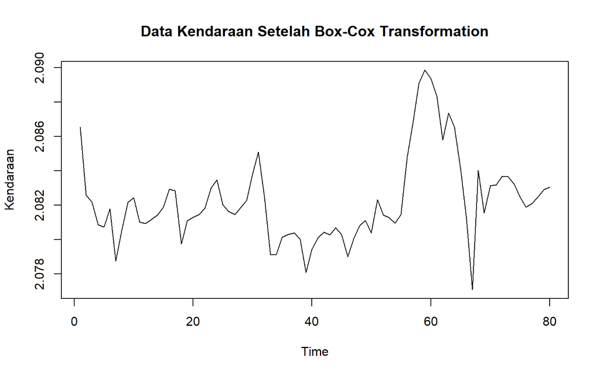

```r
plot.ts(data.transformasi, main="Data Kendaraan Setelah Box-Cox Transformation")
```

Berdasarkan plot data setelah di transformasi, terlihat bahwa plot belum stasioner dalam rataan, maka diperlukan Difference Data.

#### Difference ke-1

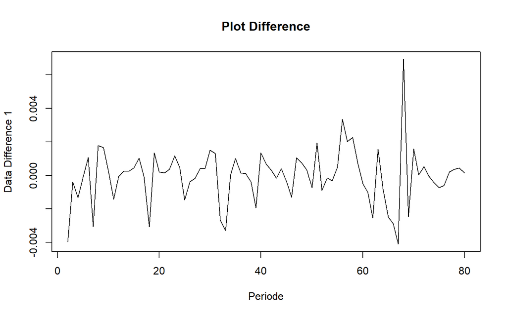

```r
train.diff<-diff(data.transformasi,differences = 1)
plot.ts(train.diff, lty=1, xlab="Periode", ylab="Data Difference 1", main="Plot Difference")
```

Berdasarkan plot data deret waktu, terlihat bahwa data belum sepenuhnya stasioner. Terdapat fluktuasi yang cukup besar dan varians yang tidak stabil, terutama di sekitar periode 60. Oleh karena itu, mungkin masih diperlukan differencing tambahan untuk mencapai stasionaritas penuh.

#### Difference ke-2

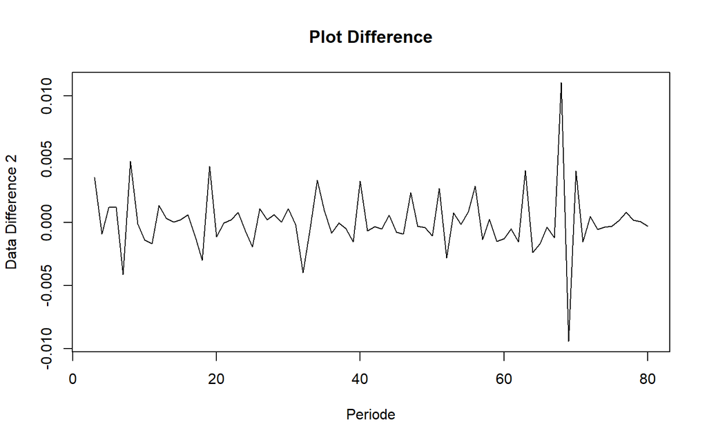

```r
train.diff2<-diff(data.transformasi,differences = 2)
plot.ts(train.diff2, lty=1, xlab="Periode", ylab="Data Difference 2", main="Plot Difference")
```

Berdasarkan plot data deret waktu, terlihat bahwa data sudah stasioner dalam rataan ditandai dengan data bergerak pada nilai tengah tertentu (tidak terdapat trend ataupun musiman pada data)

#### Plot ACF

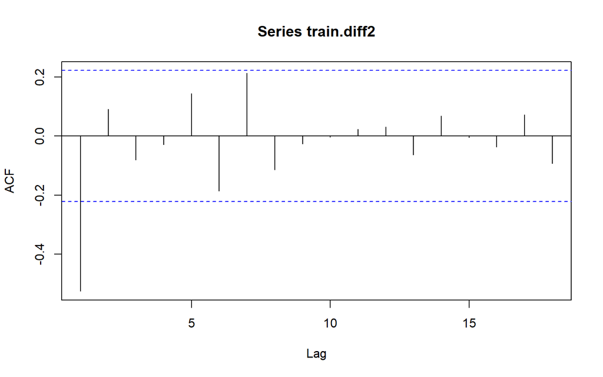

```r
acf(train.diff2)
```

Berdasarkan plot tersebut, terlihat bahwa plot ACF cuts off pada lag ke 1. Hal ini menandakan data sudah stasioner dalam rataan dan ketidakstasioneran data telah berhasil tertangani.

#### Uji ADF

```r
tseries::adf.test(train.diff2)
```

```
##
##  Augmented Dickey-Fuller Test
##
## data:  train.diff2
## Dickey-Fuller = -5.981, Lag order = 4, p-value = 0.01
## alternative hypothesis: stationary
```

$H_0$ : Data tidak stasioner dalam rataan

$H_1$ : Data stasioner dalam rataan

Berdasarkan uji ADF tersebut, didapat *p-value* sebesar 0.01 yang lebih kecil dari taraf nyata 5% sehingga tolak $H_0$ atau data stasioner dalam rataan. Hal ini sesuai dengan hasil eksplorasi menggunakan plot time series dan plot ACF, sehingga dalam hal ini ketidakstasioneran data sudah berhasil ditangani dan dapat dilanjutkan ke pemodelan

### Identifikasi Model

#### Plot ACF

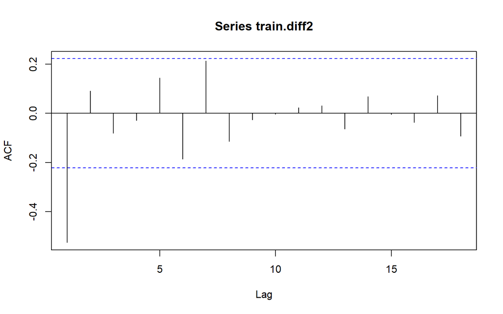

```r
acf(train.diff2)
```

Berdasarkan plot tersebut, terlihat bahwa plot ACF cenderung *cuts off* pada lag ke 1, sehingga jika plot PACF dianggap *tails of*, maka model tentatifnya adalah ARIMA(0,2,1).

#### Plot PACF

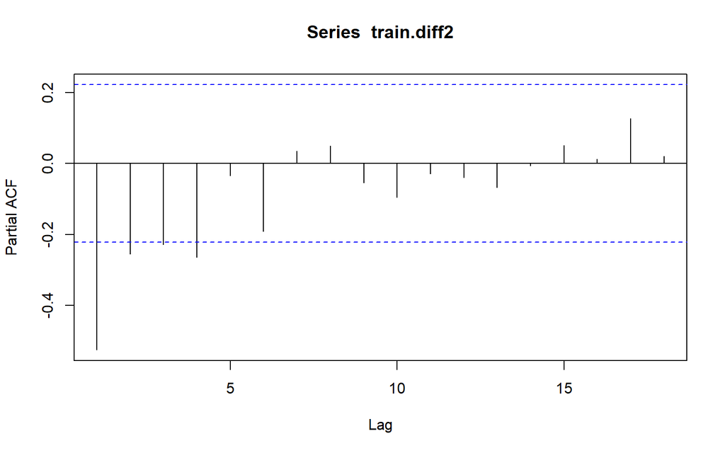

```r
pacf(train.diff2)
```

Jika baik plot ACF maupun plot PACF keduanya dianggap tails of, maka model yang terbentuk adalah ARIMA(1,2,1)

#### Plot EACF

```r
eacf(train.diff2)
```

```
## AR/MA
##   0 1 2 3 4 5 6 7 8 9 10 11 12 13
## 0 x o o o o o o o o o o  o  o  o
## 1 x x o o o o o o o o o  o  o  o
## 2 x o x o o o o o o o o  o  o  o
## 3 x o x o o o o o o o o  o  o  o
## 4 o x x x o o o o o o o  o  o  o
## 5 o x x o o x o o o o o  o  o  o
## 6 o o x x x x x o o o o  o  o  o
## 7 o o o o o o o o o o o  o  o  o
```

Identifikasi model menggunakan plot EACF dilakukan dengan melihat ujung segitiga pada pola segitiga nol. Dalam hal ini model tentatif yang terbentuk adalah ARIMA(0,2,1) ARIMA(1,2,2) dan ARIMA(2,2,3).

### Pendugaan Parameter Model Tentatif

#### ARIMA(0,2,1)

```r
model1.da=Arima(train.diff2, order=c(0,2,1),method="ML")
summary(model1.da) #AIC= -607.65
```

```
## Series: train.diff2
## ARIMA(0,2,1)
##
## Coefficients:
##           ma1
##       -1.0000
## s.e.   0.0325
##
## sigma^2 = 1.792e-05:  log likelihood = 305.83
## AIC=-607.65   AICc=-607.49   BIC=-602.99
##
## Training set error measures:
##                        ME        RMSE         MAE      MPE     MAPE      MASE
## Training set 0.0002027115 0.004150528 0.002473207 74.86196 341.1254 0.9749303
##                    ACF1
## Training set -0.6882194
```

```r
lmtest::coeftest(model1.da) #seluruh parameter signifikan
```

```
##
## z test of coefficients:
##
##      Estimate Std. Error z value  Pr(>|z|)
## ma1 -1.000000   0.032506 -30.763 < 2.2e-16 ***
## ---
## Signif. codes:  0 '***' 0.001 '**' 0.01 '*' 0.05 '.' 0.1 ' ' 1
```

#### ARIMA(1,2,0)

```r
model2.da=Arima(train.diff2, order=c(1,2,0),method="ML")
summary(model2.da) #AIC= -590.16
```

```
## Series: train.diff2
## ARIMA(1,2,0)
##
## Coefficients:
##           ar1
##       -0.7750
## s.e.   0.0702
##
## sigma^2 = 2.359e-05:  log likelihood = 297.08
## AIC=-590.16   AICc=-589.99   BIC=-585.5
##
## Training set error measures:
##                        ME        RMSE         MAE       MPE     MAPE    MASE
## Training set 6.495898e-05 0.004762893 0.003376815 -180.8063 770.5412 1.33113
##                    ACF1
## Training set -0.4590825
```

```r
lmtest::coeftest(model2.da) #seluruh parameter signifikan
```

```
##
## z test of coefficients:
##
##      Estimate Std. Error z value  Pr(>|z|)
## ar1 -0.775020   0.070226 -11.036 < 2.2e-16 ***
## ---
## Signif. codes:  0 '***' 0.001 '**' 0.01 '*' 0.05 '.' 0.1 ' ' 1
```

#### ARIMA(1,2,1)

```r
model3.da=Arima(train.diff2, order=c(1,2,1),method="ML")
summary(model3.da) #AIC=-655.55
```

```
## Series: train.diff2
## ARIMA(1,2,1)
##
## Coefficients:
##           ar1      ma1
##       -0.6944  -1.0000
## s.e.   0.0810   0.0331
##
## sigma^2 = 9.209e-06:  log likelihood = 330.77
## AIC=-655.55   AICc=-655.21   BIC=-648.56
##
## Training set error measures:
##                        ME        RMSE         MAE      MPE    MAPE      MASE
## Training set 0.0001688437 0.002955785 0.001925419 31.86249 345.082 0.7589941
##                    ACF1
## Training set -0.3141811
```

```r
lmtest::coeftest(model3.da) #seluruh parameter signifikan
```

```
##
## z test of coefficients:
##
##      Estimate Std. Error z value  Pr(>|z|)
## ar1 -0.694390   0.080978  -8.575 < 2.2e-16 ***
## ma1 -1.000000   0.033148 -30.168 < 2.2e-16 ***
## ---
## Signif. codes:  0 '***' 0.001 '**' 0.01 '*' 0.05 '.' 0.1 ' ' 1
```

#### ARIMA(1,2,2)

```r
model5.da=Arima(train.diff2, order=c(1,2,2),method="ML")
summary(model5.da) #AIC= -702.41
```

```
## Series: train.diff2
## ARIMA(1,2,2)
##
## Coefficients:
##           ar1      ma1     ma2
##       -0.5179  -1.9927  1.0000
## s.e.   0.0982   0.0520  0.0511
##
## sigma^2 = 4.408e-06:  log likelihood = 355.2
## AIC=-702.41   AICc=-701.84   BIC=-693.08
##
## Training set error measures:
##                        ME        RMSE         MAE      MPE     MAPE     MASE
## Training set 0.0002178526 0.002031214 0.001408672 190.5784 275.4243 0.555294
##                    ACF1
## Training set -0.1278397
```

```r
lmtest::coeftest(model5.da) #seluruh parameter signifikan
```

```
##
## z test of coefficients:
##
##      Estimate Std. Error  z value  Pr(>|z|)
## ar1 -0.517917   0.098225  -5.2728 1.344e-07 ***
## ma1 -1.992683   0.052017 -38.3083 < 2.2e-16 ***
## ma2  0.999971   0.051140  19.5535 < 2.2e-16 ***
## ---
## Signif. codes:  0 '***' 0.001 '**' 0.01 '*' 0.05 '.' 0.1 ' ' 1
```

#### ARIMA(2,2,3)

```r
model6.da=Arima(train.diff, order=c(2,2,3),method="ML")
summary(model6.da) #AIC=-740.28
```

```
## Series: train.diff
## ARIMA(2,2,3)
##
## Coefficients:
##           ar1     ar2      ma1     ma2     ma3
##       -0.3494  0.0346  -1.6873  0.3845  0.3083
## s.e.   0.6901  0.1268   0.6812  1.3533  0.6776
##
## sigma^2 = 2.983e-06:  log likelihood = 376.74
## AIC=-741.48   AICc=-740.28   BIC=-727.42
##
## Training set error measures:
##                         ME        RMSE         MAE      MPE     MAPE      MASE
## Training set -0.0003461372 0.001648926 0.001107181 100.2747 148.4414 0.7410513
##                     ACF1
## Training set -0.01072396
```

```r
lmtest::coeftest(model6.da) #terdapat parameter tidak signifikan
```

```
##
## z test of coefficients:
##
##      Estimate Std. Error z value Pr(>|z|)
## ar1 -0.349409   0.690056 -0.5063  0.61261
## ar2  0.034574   0.126812  0.2726  0.78513
## ma1 -1.687285   0.681219 -2.4769  0.01325 *
## ma2  0.384515   1.353306  0.2841  0.77631
## ma3  0.308346   0.677575  0.4551  0.64906
## ---
## Signif. codes:  0 '***' 0.001 '**' 0.01 '*' 0.05 '.' 0.1 ' ' 1
```